# CamEnergy Data Lab: Challenge 1 - Energy Production Data Simulation

The challenge here is to predict the PV Energy production of 500 houses based on historic data (Temperature and Daylight). Here's a data sample:

```
ID  Label  House  Year  Month  Temperature  Daylight  EnergyProduction
```

```
0   0      1      2011  7      26.2         178.9     740
```

```
1   1      1      2011  8      25.8         169.7     731
```

```
2   2      1      2011  9      22.8         170.2     694
```

```
3   3      1      2011  10     16.4         169.1     688
```

```
#To display plots in the same window
```

```
%pylab inline
```

```
Welcome to pylab, a matplotlib-based Python environment [backend: module://IPython.zmq.pylab.backend_inline].
For more information, type 'help(pylab)'.
```

```
import numpy as np
```

```
import pylab as pl
```

```
from sklearn import feature_selection
```

```
from sklearn import preprocessing
```

```
from sklearn import linear_model
```

```
from sklearn import svm
```

```
from sklearn import neighbors
```

```
from sklearn import ensemble
```

```
from sklearn import grid_search
```

```
from sklearn import metrics
```

```
from utility_extra import mape
```

Load data

```
# 0-ID  1-Label  2-House  3-Year  4-Month  5-Temperature  6-Daylight  7-EnergyProduction
```

```
data_train = np.loadtxt("../../data/training_dataset_500.csv", delimiter=',', skiprows=1)
```

```
data_test = np.loadtxt("../../data/test_dataset_500.csv", delimiter=',', skiprows=1)
```

```
x_train = data_train[:, :7]
```

```
y_train = data_train[:, 7]
```

```
x_test = data_test[:, :7]
```

```
y_test = data_test[:, 7]
```

Data preprocessing, I scaled and normalized data, but only scaling helped the fit.

```
scaler = preprocessing.StandardScaler()
```

```
x_train = scaler.fit_transform(x_train)
```

```
x_test = scaler.transform(x_test)
```

```
#normalizer = preprocessing.Normalizer()
```

```
#x_train = normalizer.fit_transform(x_train)
```

```
#x_test = normalizer.transform(x_test)
```

Intuitively it seems like the most important parameters/dimensions should be: House, Month, Temperature and Daylight. But to be sure (maybe the data were tricked??) I did a univariate feature selection. I did a SVM regression and looked at the weight of the individual parameters.

```
# Univariate feature selection with F-test for feature scoring
```

```
selector = feature_selection.SelectPercentile(feature_selection.f_regression, percentile=60)
```

```
selector.fit(x_train, y_train)
```

```
clf = svm.SVR(kernel='linear')
```

```
clf.fit(x_train, y_train)
```

```
svm_weights = (clf.coef_ ** 2).sum(axis=0)
```

```
svm_weights /= svm_weights.max()
```

```
clf_selected = svm.SVR(kernel='linear')
```

```
clf_selected.fit(selector.transform(x_train), y_train)
```

```
svm_weights_selected = (clf_selected.coef_ ** 2).sum(axis=0)
```

```
svm_weights_selected /= svm_weights_selected.max()
```

```
print "MAPE score linear SVR: ", mape( y_test, clf.predict(x_test))
```

```
print "MAPE score linear SVR with selector: ", mape( y_test, clf_selected.predict(selector.transform(x_test)))
```

```
MAPE score linear SVR:  16.9646647905
MAPE score linear SVR with selector:  16.9136222627
```

Plot results:

```
X_indices = np.arange(x_train.shape[-1])
```

```
pl.bar(X_indices - .25, svm_weights, width=.2, label='SVR weight', color='r')
```

```
pl.bar(X_indices[selector.get_support()] - .05, svm_weights_selected, width=.2,
```

```
       label='SVR weights after selection', color='b')
```

```
pl.title("Comparing feature selection")
```

```
pl.xlabel('Feature number')
```

```
pl.xticks(X_indices,['ID',  'Label', 'House', 'Year', 'Month', 'Temperature', 'Daylight'])
```

```
pl.axis('tight')
```

```
pl.legend(loc='upper left')
```

```
pl.show()
```

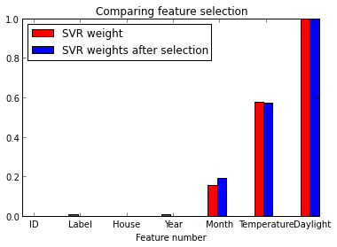

Something seems odd, the 'House' parameter has no weight at all, but we would expect wide variations from home to home. Let's look at the data for the relevent parameters and do a linear regression to get a sense of what's going on:

```
regr = linear_model.LinearRegression()
```

```
regr.fit(x_train, y_train)
```

```
pred = regr.predict(x_test)
```

```
print "MAPE: ", mape(y_test, regr.predict(x_test)), "%"
```

```
MAPE:  14.4487735895 %
```

```
xlabel = ['House','Month','Temperature','Daylight']
```

```
data_col = [2, 4, 5, 6]
```

```
for i, icol in enumerate(data_col):
```

```
    plt.subplot(2, 2, i + 1)
```

```
    plt.scatter(x_train[:, icol], y_train, s=1)
```

```
    xr = np.asarray([min(x_train[:, icol]), max(x_train[:, icol])])
```

```
    yr = xr * regr.coef_[icol] + regr.intercept_
```

```
    plt.plot(xr, yr, color = 'red')
```

```
    pl.axis('tight')
```

```
    plt.title(xlabel[i])
```

```
    plt.ylabel('E')
```

```
    subplots_adjust(hspace=.35)
```

```
plt.show()
```

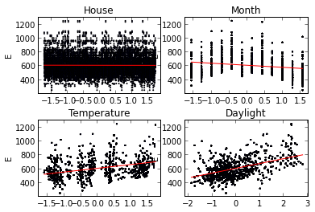

```
# Columns of data:
```

```
# 0-ID  1-Label  2-House  3-Year  4-Month  5-Temperature  6-Daylight  7-MeanEnergyProduction 8-DiffE
```

```
data_train = np.loadtxt("../../data/training_dataset_500_nh.csv", delimiter=',')
```

```
data_test = np.loadtxt("../../data/test_dataset_500_nh.csv", delimiter=',')
```

```
x_train = data_train[:, [4, 5, 6, 7]]
```

```
y_train = data_train[:,8]
```

```
x_test = data_test[:, [4, 5, 6, 7]]
```

```
y_test = data_test[:, 8]
```

```
scaler = preprocessing.StandardScaler()
```

```
x_train = scaler.fit_transform(x_train)
```

```
x_test = scaler.transform(x_test)
```

Then I tested a few models:

```
regr = linear_model.LinearRegression()
```

```
regr.fit(x_train, y_train)
```

```
pred = regr.predict(x_test)
```

```
print "Lin reg"
```

```
print "MAPE: ", mape(y_test, regr.predict(x_test))
```

```
ridge = linear_model.Ridge(alpha = 0.5)
```

```
ridge.fit(x_train, y_train)
```

```
print "Ridge"
```

```
print "MAPE: ", mape(y_test, ridge.predict(x_test))
```

```
lasso = linear_model.Lasso(alpha = 0.1)
```

```
lasso.fit(x_train, y_train)
```

```
print "Lasso"
```

```
print "MAPE: ", mape(y_test, lasso.predict(x_test))
```

```
lassolars = linear_model.LassoLars(alpha = 0.1)
```

```
lassolars.fit(x_train, y_train)
```

```
print "LAssoLars"
```

```
print "MAPE: ", mape(y_test, lassolars.predict(x_test))
```

```
lassocv = linear_model.LassoCV()
```

```
lassocv.fit(x_train, y_train)
```

```
print "LassoCV"
```

```
print "MAPE: ", mape(y_test, lassocv.predict(x_test))
```

```
lassolarscv = linear_model.LassoLarsCV()
```

```
lassolarscv.fit(x_train, y_train)
```

```
print "LassoLarsCV"
```

```
print "MAPE: ", mape(y_test, lassolarscv.predict(x_test))
```

```
alpha =0.1
```

```
enet = linear_model.ElasticNet(alpha=alpha)
```

```
enet.fit(x_train, y_train)
```

```
print "ElasticNet"
```

```
print "MAPE: ", mape( y_test, enet.predict(x_test))
```

```
neigh = neighbors.KNeighborsRegressor(n_neighbors=5)
```

```
neigh.fit(x_train, y_train)
```

```
print "KN n=5"
```

```
print "MAPE: ", mape( y_test, neigh.predict(x_test))
```

```
neigh = neighbors.KNeighborsRegressor(n_neighbors=10)
```

```
neigh.fit(x_train, y_train)
```

```
print "KN n=10"
```

```
print "MAPE: ", mape( y_test, neigh.predict(x_test))
```

```
neigh = neighbors.KNeighborsRegressor(n_neighbors=100)
```

```
neigh.fit(x_train, y_train)
```

```
print "KN n=100"
```

```
print "MAPE: ", mape( y_test, neigh.predict(x_test))
```

```
svr = svm.SVR(kernel='linear')
```

```
svr.fit(x_train, y_train)
```

```
print "SVR lin"
```

```
print "MAPE: ", mape( y_test, svr.predict(x_test))
```

```
svr = svm.SVR(kernel='poly', degree=3)
```

```
svr.fit(x_train, y_train)
```

```
print "SVR poly 3"
```

```
print "MAPE: ", mape( y_test, svr.predict(x_test))
```

```
svr = svm.SVR(kernel='rbf')
```

```
svr.fit(x_train, y_train)
```

```
print "SVR RBF"
```

```
print "MAPE: ", mape( y_test, svr.predict(x_test))
```

```
sgd = linear_model.SGDRegressor()
```

```
sgd.fit(x_train, y_train)
```

```
print "SGD"
```

```
print "MAPE: ", mape( y_test, sgd.predict(x_test))
```

```
rfr = ensemble.RandomForestRegressor()
```

```
rfr.fit(x_train, y_train)
```

```
print "RFR"
```

```
print "MAPE: ", mape( y_test, rfr.predict(x_test))
```

```
Lin reg
MAPE:  8.6778522769
Ridge
MAPE:  8.67765275195
Lasso
MAPE:  6.95951541302
LAssoLars
MAPE:  7.43030354696
LassoCV
MAPE:  8.67230259777
LassoLarsCV
MAPE:  8.6778522769
ElasticNet
MAPE:  7.11962201835
KN n=5
MAPE:  8.0962790506
KN n=10
MAPE:  8.10867176165
KN n=100
MAPE:  6.75761797342
SVR lin
MAPE:  8.85601441977
SVR poly 3
MAPE:  9.12858342767
SVR RBF
MAPE:  13.5249930939
SGD
MAPE:  8.69262369569
RFR
MAPE:  6.37785471112
```

That's not bad, but I tried to do a grid search to see if I could improve the fit with better fitting parameters for the SVR and RFR models. The best results were with Random Forest Regression.

```
rfr = ensemble.RandomForestRegressor(n_estimators=300, max_features='sqrt', min_samples_split=10, min_samples_leaf=2)
```

```
rfr.fit(x_train, y_train)
```

```
print "RFR"
```

```
print "MAPE: ", mape( y_test, rfr.predict(x_test))
```

```
RFR
MAPE:  6.1616679983
```

That seems pretty good, let's now see what the predictions looks like:

```
y_pred = rfr.predict(x_test)
```

```
y_pred = y_pred * data_test[:, 7]
```

```
y_test = y_test * data_test[:, 7]
```

```
pl.scatter(y_test, y_pred, cmap=pl.cm.Paired)
```

```
low = min(np.append(y_test, y_pred))
```

```
hig = max(np.append(y_test, y_pred))
```

```
pl.plot([low,hig], [low,hig], '-')
```

```
pl.xlabel('True Energy Produced')
```

```
pl.ylabel('Predicted Energy Produced')
```

```
pl.show()
```

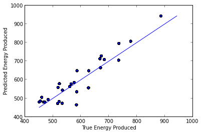

```
pl.hist(abs(y_test - y_pred))
```

```
pl.xlabel('Error')
```

```
pl.ylabel('N')
```

```
pl.title('Histogram of errors')
```

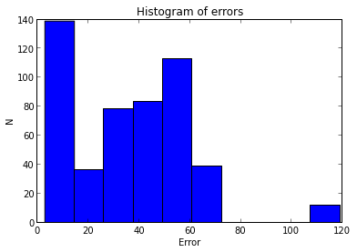

```
print 'Root mean square error: ', np.sqrt(metrics.mean_squared_error(y_test, y_pred))
```

```
Root mean square error:  43.8120534491
```

So the prediction seems pretty good, except for 12 houses where the prediction is quite different. Perhaps a closer look at those specific houses is required.